Skip to contents

# Visualization of communities and higher-order networks

Mohammed SaqrSonsoles López-Pernas

2026-03-14

Source: [`vignettes/articles/cograph-tutorial-communities.qmd`](https://github.com/sonsoleslp/cograph/blob/main/vignettes/articles/cograph-tutorial-communities.qmd)

## 1 Introduction

cograph provides two functions for visualizing community structure and higher-order relationships in networks:

- **`overlay_communities()`** — renders a network with `splot()` and overlays smooth blob shapes highlighting communities
- **`plot_simplicial()`** — visualizes higher-order pathways (simplicial complexes) as blobs on a ggplot2 canvas

Both accept any network type: `tna`, matrix, `igraph`, or `cograph_network`.

We use a TNA model of collaborative group regulation throughout:

```r
model <- tna(group_regulation)
```

## 2 overlay_communities()

### 2.1 Method Name

The simplest way: pass an igraph community detection method name. Partial matching and flexible naming are supported.

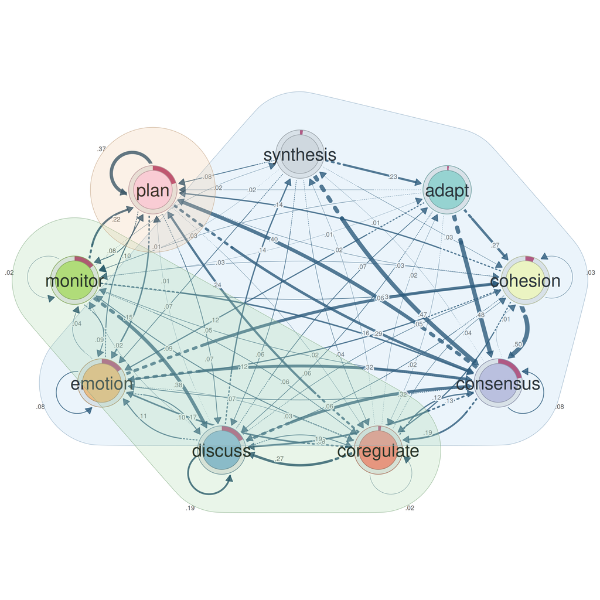

```r
overlay_communities(model, "fast_greedy")
```

Any igraph `cluster_*` method works: `"walktrap"`, `"louvain"`, `"fast_greedy"`, `"leading_eigen"`, `"infomap"`, `"leiden"`, `"label_prop"`, `"edge_betweenness"`, `"spinglass"`, `"optimal"`, `"fluid_communities"`. You can use the full igraph name (`"cluster_walktrap"`), the short name (`"walktrap"`), or a partial match (`"leading_eige"`). Directed graphs are automatically converted to undirected for detection.

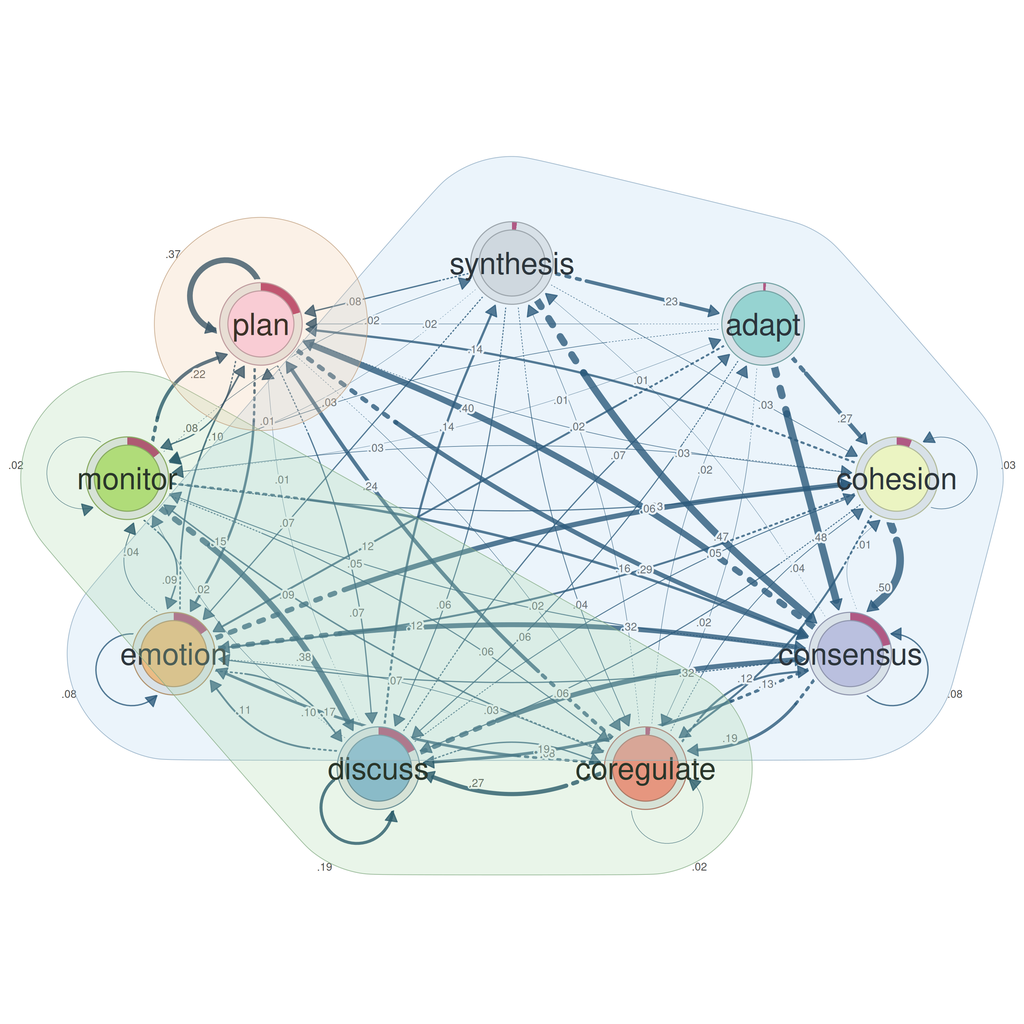

```r
overlay_communities(model, "louvain")
```

### 2.2 Named List

Define communities manually with a named list:

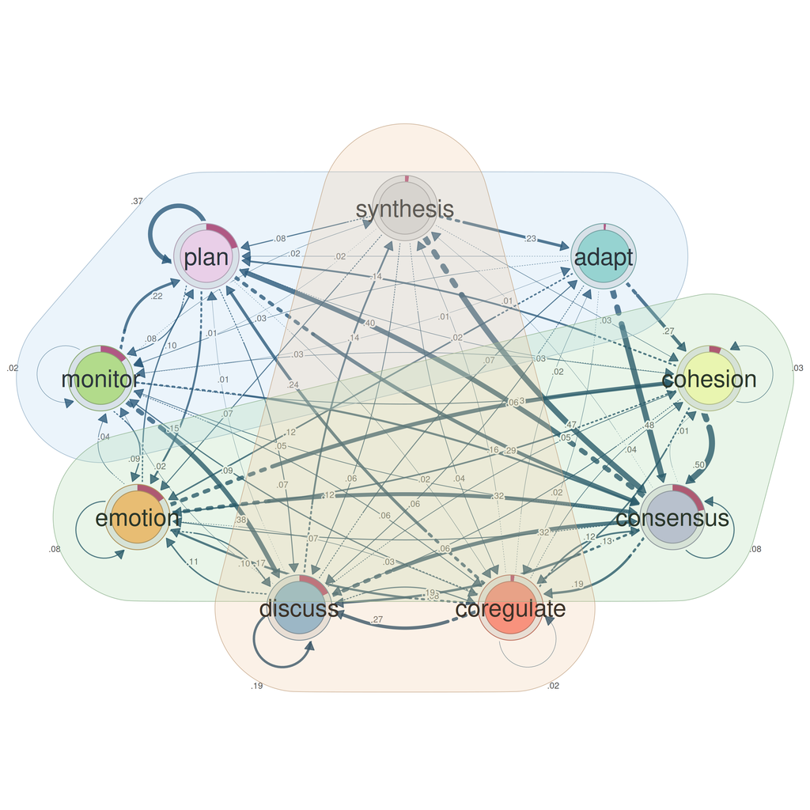

```r
overlay_communities(model, list(
  Regulatory = c("plan", "monitor", "adapt"),
  Social     = c("cohesion", "emotion", "consensus"),
  Task       = c("discuss", "synthesis", "coregulate")
))
```

### 2.3 Membership Vector

A numeric vector or factor where each position maps to a node:

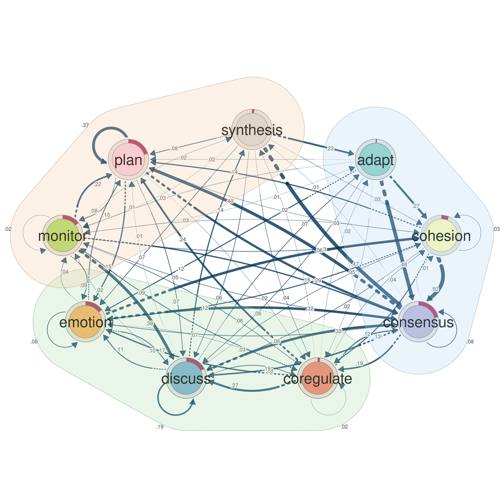

```r
overlay_communities(model, c(1, 1, 1, 2, 2, 2, 3, 3, 3))
```

### 2.4 Custom Colors

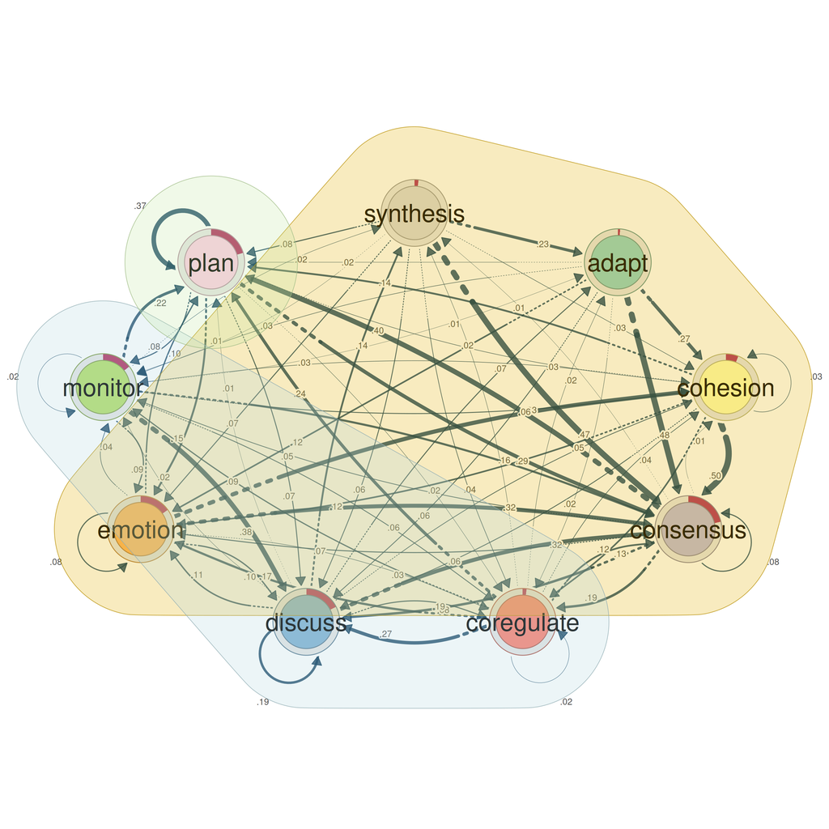

```r
overlay_communities(model, "louvain", blob_colors = c("#E5B000", "#B4D7E0", "#C5E8A4"))
```

### 2.5 Overlapping Communities

Communities can share nodes:

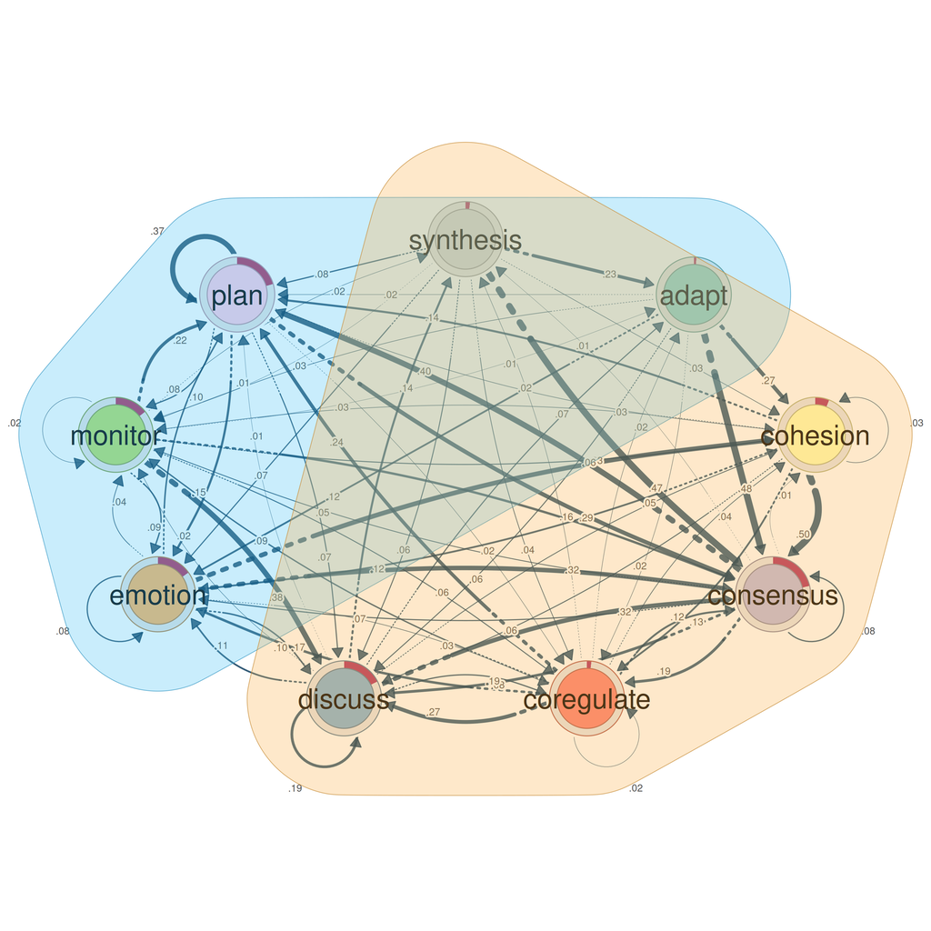

```r
overlay_communities(model, list(
  "Self-Regulation" = c("plan", "monitor", "adapt", "emotion"),
  Collaboration     = c("cohesion", "consensus", "discuss",
                         "coregulate", "synthesis")
), blob_colors = c("#4FC3F7", "#fbb550"), blob_alpha = 0.30)
```

## 3 plot_simplicial()

`plot_simplicial()` visualizes higher-order pathways as smooth blob shapes over a network layout. Source nodes appear in blue, target nodes in red.

### 3.1 Manual Pathways

You can specify pathways directly as strings:

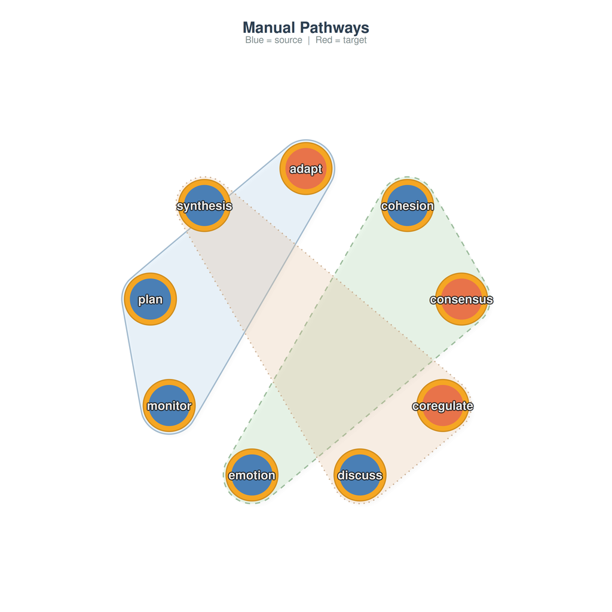

```r
plot_simplicial(model, c(
  "plan monitor -> adapt",
  "cohesion emotion -> consensus",
  "discuss synthesis -> coregulate"
), title = "Manual Pathways")
```

### 3.2 Auto-Built from HON

When given a `netobject` (from Nestimate), `plot_simplicial()` automatically builds a Higher-Order Network and extracts the most frequent pathways where sequential context changes the transition distribution:

```r
library(Nestimate)
net <- build_network(group_regulation, method = "relative")
```

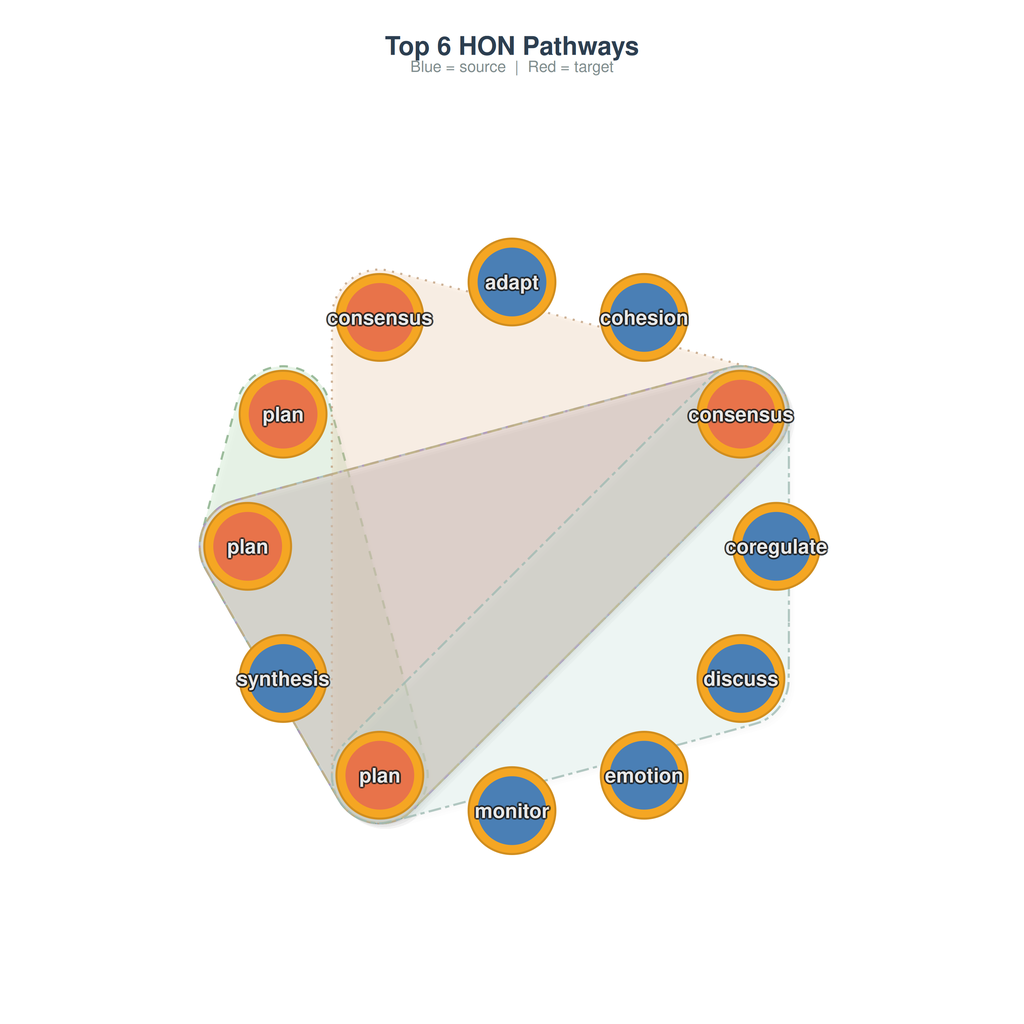

```r
plot_simplicial(net, max_pathways = 6,
  title = "Top 6 HON Pathways")
```

### 3.3 Dismantled View

One panel per pathway — easier to read individual pathways:

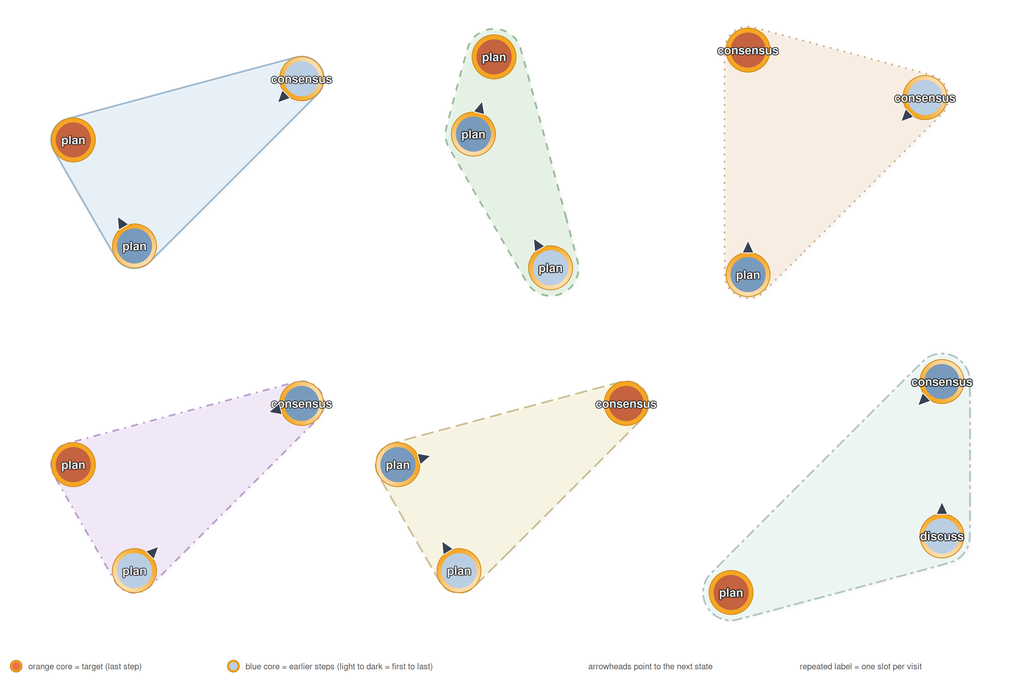

```r
plot_simplicial(net, max_pathways = 6,
  dismantled = TRUE, ncol = 3)
```

### 3.4 HYPA Anomalous Pathways

Switch to `method = "hypa"` to show paths that occur significantly more or less often than expected under a null model:

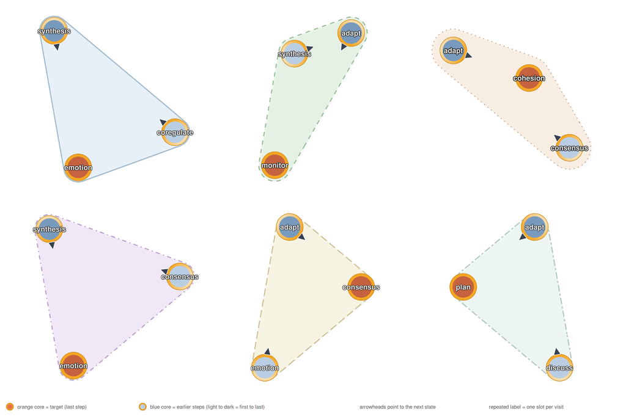

```r
plot_simplicial(net, method = "hypa", max_pathways = 6,
  dismantled = TRUE, ncol = 3)
```

### 3.5 Custom Styling

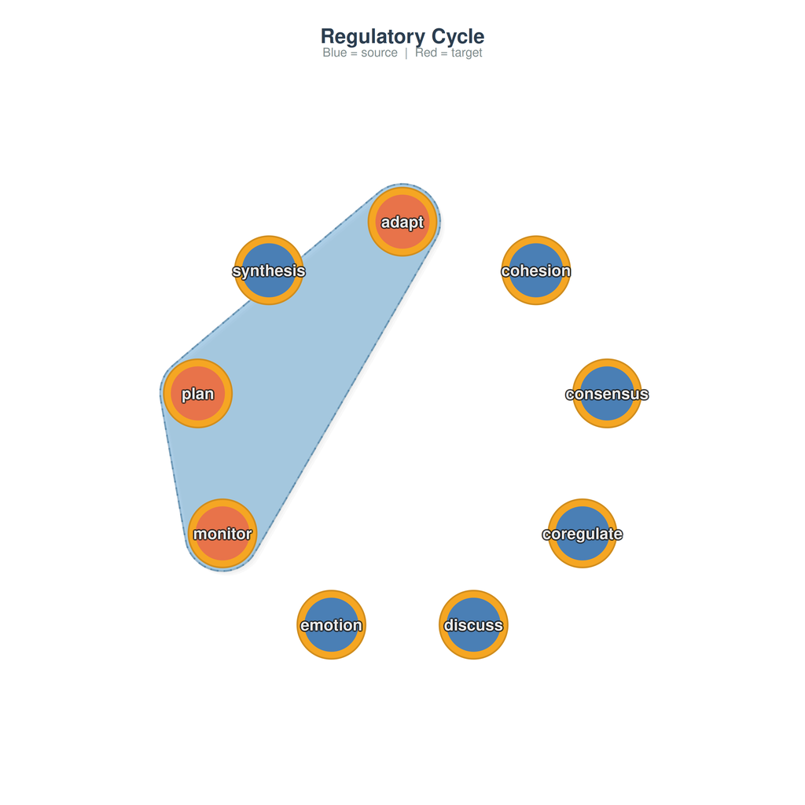

```r
plot_simplicial(model,
  c("plan monitor -> adapt",
    "adapt monitor -> plan",
    "plan adapt -> monitor"),
  blob_colors = c("#B0D4F1", "#8BBDE0", "#6AA6CF"),
  blob_alpha = 0.30,
  title = "Regulatory Cycle"
)
```